# Why Do Employees Quit Prematurely?

December 19, 2017

## Packages Employed

```r
library(plyr)
library(scales)
library(tidyverse)
library(ggplot2)
library(ggcorrplot)
library(ggthemes)
library(formattable)
library(htmlwidgets)
library(ggalt)
library(party)
library(rpart)
library(rpart.plot)
library(pROC)
```

## Human Resources Data Set

[Human Resources Analytics Data](https://www.kaggle.com/ludobenistant/hr-analytics/data) from [kaggle](https://www.kaggle.com) with 14999x10 rows&columns

```
## Observations: 14,999
## Variables: 10
## $ satisfaction_level    <dbl> 0.38, 0.80, 0.11, 0.72, 0.37, 0.41, 0.10...
## $ last_evaluation       <dbl> 0.53, 0.86, 0.88, 0.87, 0.52, 0.50, 0.77...
## $ number_project        <int> 2, 5, 7, 5, 2, 2, 6, 5, 5, 2, 2, 6, 4, 2...
## $ average_montly_hours  <int> 157, 262, 272, 223, 159, 153, 247, 259, ...
## $ time_spend_company    <int> 3, 6, 4, 5, 3, 3, 4, 5, 5, 3, 3, 4, 5, 3...
## $ Work_accident         <int> 0, 0, 0, 0, 0, 0, 0, 0, 0, 0, 0, 0, 0, 0...
## $ left                  <int> 1, 1, 1, 1, 1, 1, 1, 1, 1, 1, 1, 1, 1, 1...
## $ promotion_last_5years <int> 0, 0, 0, 0, 0, 0, 0, 0, 0, 0, 0, 0, 0, 0...
## $ departments           <fctr> sales, sales, sales, sales, sales, sale...
## $ salary                <fctr> low, medium, medium, low, low, low, low...
```

## Data Description

- **satisfaction_level:** Job satisfaction level (0.0 - 1.0)
- **last_evaluation:** Last evaluation score (0.0 - 1.0)
- **number_project:** Number of projects worked on (yearly basis)
- **average_montly_hours:** Average monthly working hours
- **time_spend_company:** Time spent in the company (in years)
- **Work_accident:** Whether they have had a work accident in the last 2 years (if yes 1, else 0)
- **promotion_last_5years:** Whether they have had a promotion in the last 5 years
- **departments:** Name of the department
- **salary:** Salary (low-medium-high)
- **left:** Whether the employee has left (if yes 1, else 0)

## Descriptive Statistics of the Numerical Features

```
##  satisfaction_level last_evaluation  number_project  average_montly_hours
##  Min.   :0.0900     Min.   :0.3600   Min.   :2.000   Min.   : 96.0
##  1st Qu.:0.4400     1st Qu.:0.5600   1st Qu.:3.000   1st Qu.:156.0
##  Median :0.6400     Median :0.7200   Median :4.000   Median :200.0
##  Mean   :0.6128     Mean   :0.7161   Mean   :3.803   Mean   :201.1
##  3rd Qu.:0.8200     3rd Qu.:0.8700   3rd Qu.:5.000   3rd Qu.:245.0
##  Max.   :1.0000     Max.   :1.0000   Max.   :7.000   Max.   :310.0
##  time_spend_company Work_accident         left
##  Min.   : 2.000     Min.   :0.0000   Min.   :0.0000
##  1st Qu.: 3.000     1st Qu.:0.0000   1st Qu.:0.0000
##  Median : 3.000     Median :0.0000   Median :0.0000
##  Mean   : 3.498     Mean   :0.1446   Mean   :0.2381
##  3rd Qu.: 4.000     3rd Qu.:0.0000   3rd Qu.:0.0000
##  Max.   :10.000     Max.   :1.0000   Max.   :1.0000
##  promotion_last_5years
##  Min.   :0.00000
##  1st Qu.:0.00000
##  Median :0.00000
##  Mean   :0.02127
##  3rd Qu.:0.00000
##  Max.   :1.00000
```

## Departmentwise Salary Frequencies

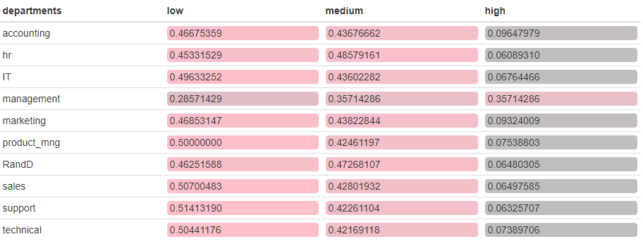

## Histograms of the Numerical Variables

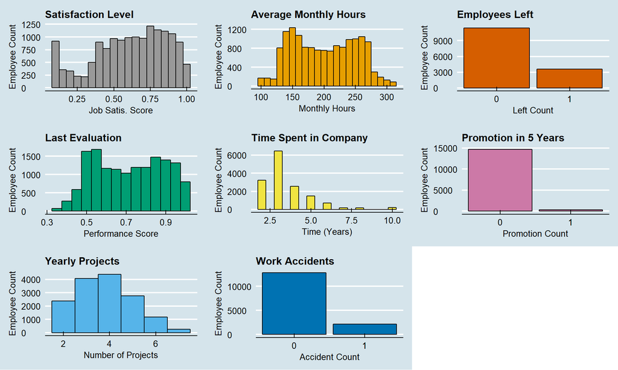

## How Many Left from Which Department?

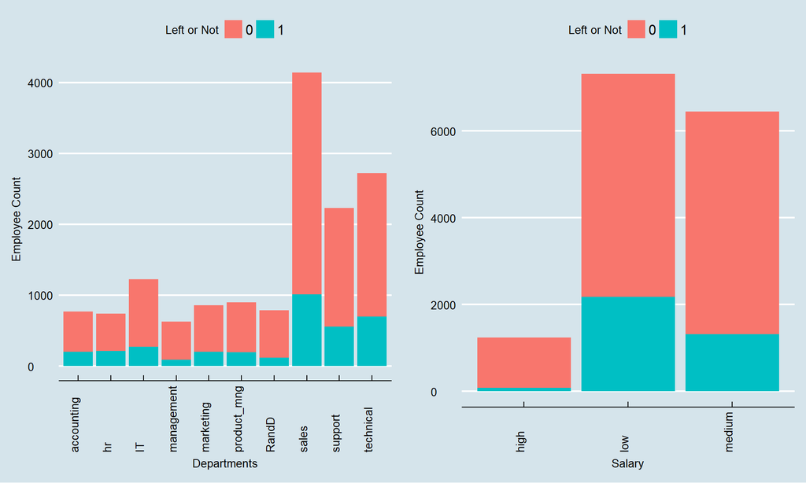

## Department Left Rate by Satisfaction & Salary

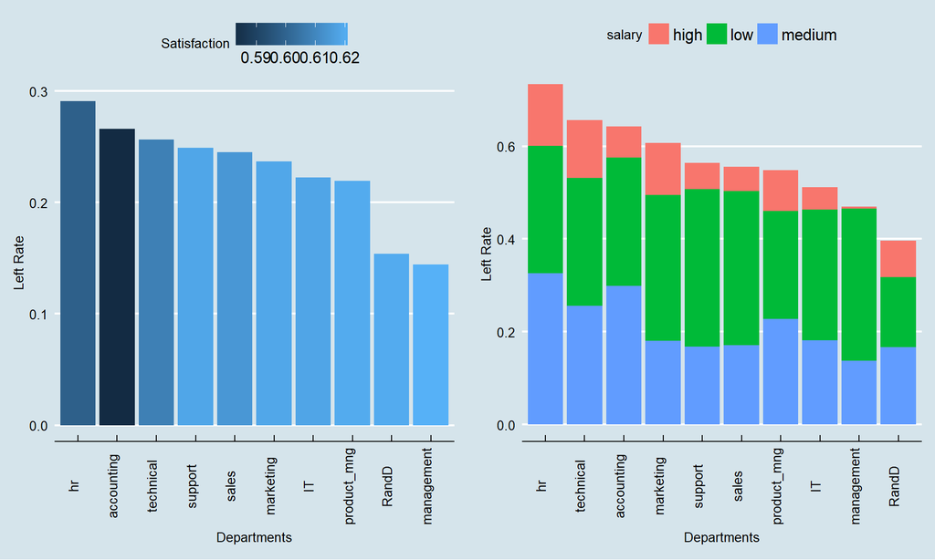

## Satisfaction vs. Working Hours

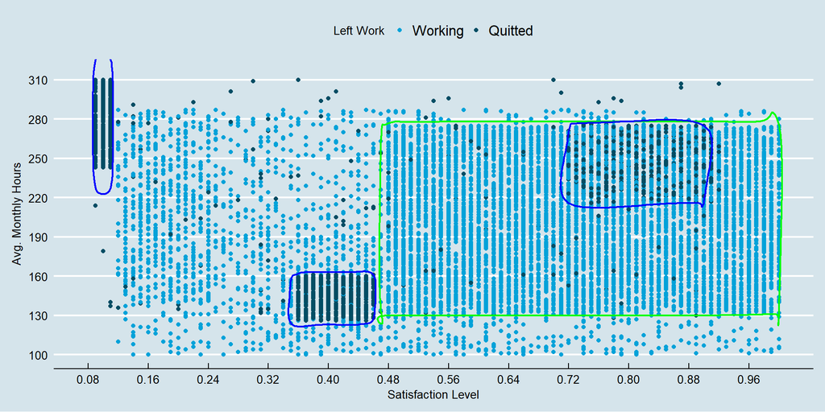

## Satisfaction vs. Time Spent

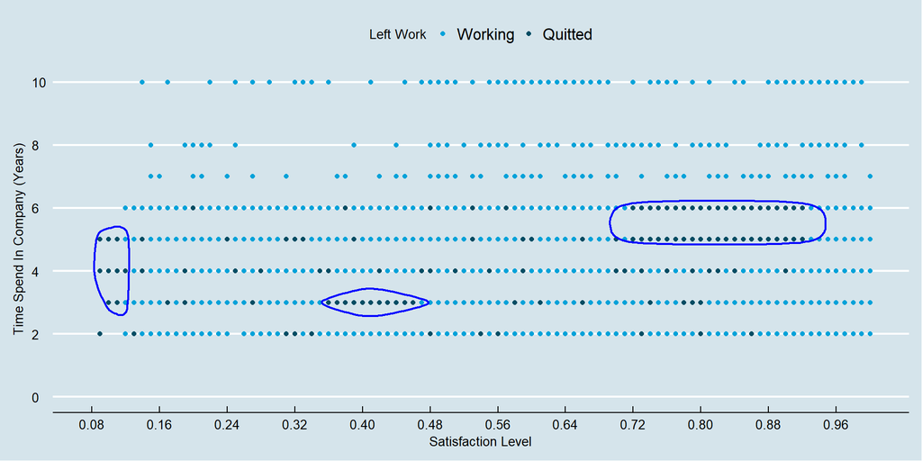

## Group Characteristics

- *Group 1:* Low satisfaction level, long working hours and leaves in medium term (3-5 years)
- *Group 2:* Mediocre satisfaction level, short working hours and leaves early (around 3 years)
- *Group 3:* High satisfaction level and high working hours and leaves late (5-6 years)

## Correlation Matrix

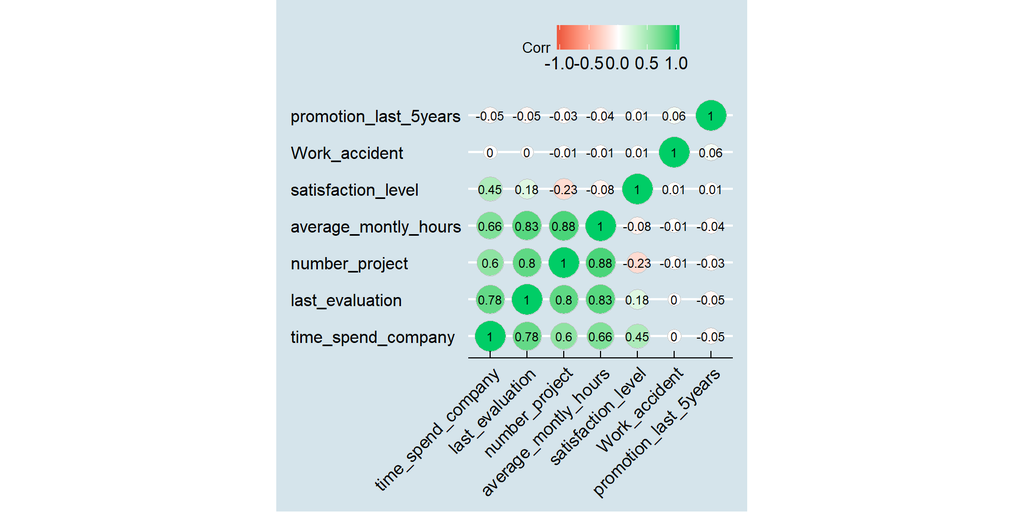

## PCA: Biplot

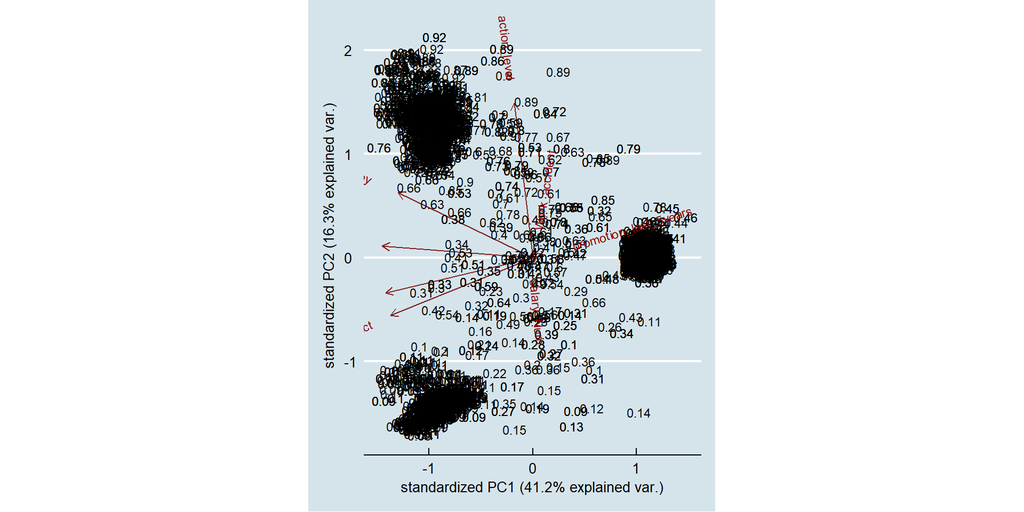

## PCA: Cumulative Variance

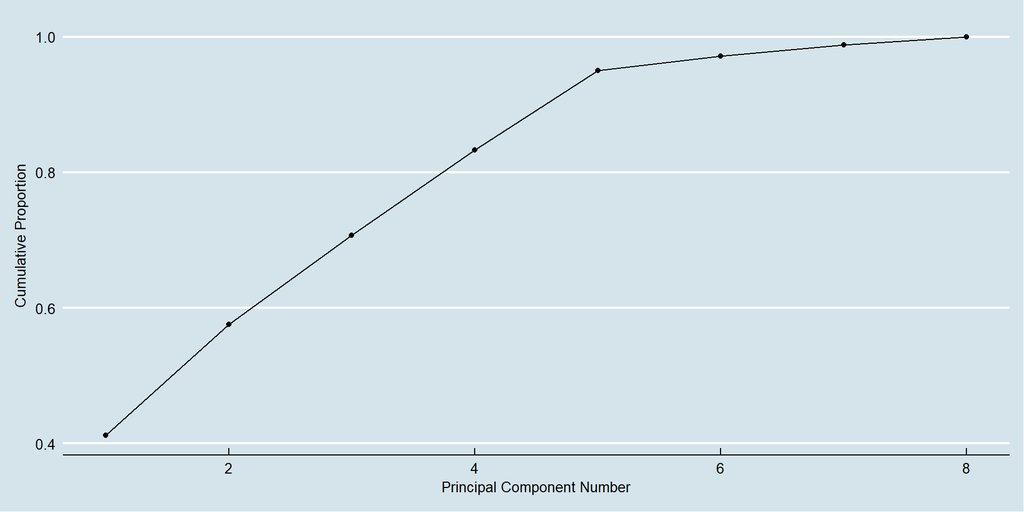

## K-Means Clustering

```
##   satisfaction_level last_evaluation number_project average_montly_hours
## 1          0.6100000       0.8891911       4.936889             243.6409
## 2          0.4159149       0.5306140       2.178723             144.8322
## 3          0.2511361       0.8628964       5.780275             285.0799
##   time_spend_company Work_accident promotion_last_5years
## 1           4.778667    0.05333333          0.0008888889
## 2           3.071733    0.04741641          0.0091185410
## 3           4.262172    0.03870162          0.0037453184
```

## Decision Tree Analysis And Prediction

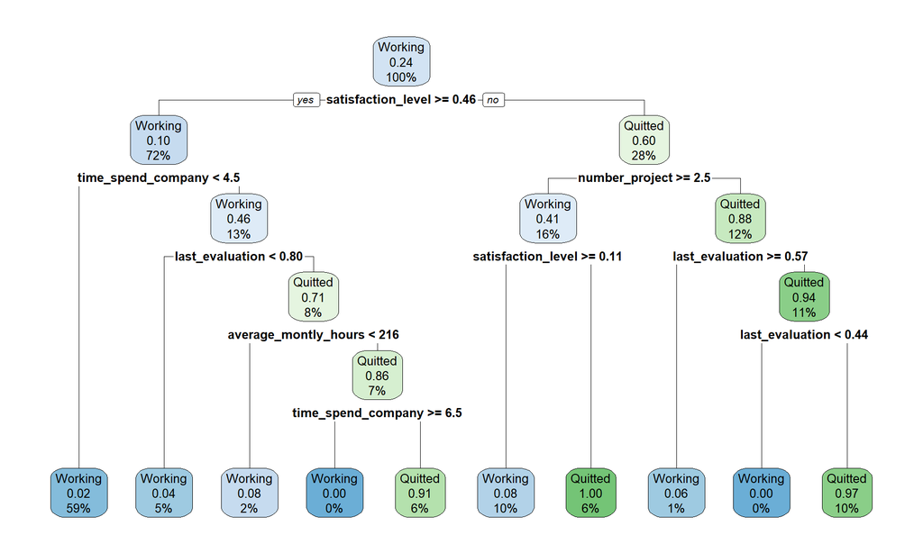

Secondary factor that determines the satisfied employees quit decision is **time spent in the company**. If someone is working in the same company between 4.5 - 6.5 years, they break their comfort zone and flee because they work for long hours (> 216 h monthly basis) even if their bosses are very happy with their work (evaluation score > 0.80). We belive that this category corresponds to patient, hardworking, motivated employees of **Cluster 1** (i.e. Group 3).

## Conclusion

- Satisfaction determines resignation. If low they quit!
- People w/ VERY LOW satisfaction can work for VERY LONG working hours, ends the contract in medium terms.
- People w/ MEDIOCRE satisfaction DO NOT work for long hours, resign quickly.
- Patient, HIGHLY satisfied, hardworking workers quit latest.
- Promotion and salary system must be improved for the good of the employees.

## References

- [Human Resources Analytics Data Set](https://www.kaggle.com/ludobenistant/hr-analytics/data)
- [Explore & Explain: Density & Decision Trees](https://www.kaggle.com/msjgriffiths/explore-explain-density-decision-trees)
- [Titanic: Getting Starting with R - Part 3: Decision Trees](http://trevorstephens.com/kaggle-titanic-tutorial/r-part-3-decision-trees/)
- [Intro to Decision Trees with R Example](https://rpubs.com/osazuwa/123908)
- [StackExchange](https://stats.stackexchange.com/questions/2038/interpretation-of-biplots-in-principal-components-analysis)